# TARRU

JcB

31/10/2015

Le taux régional de recours aux urgences (TARRU) est le nombre de passages dans les services d’urgences (de la région ou département) de patients résidant dans une zone donnée (code postal ou commune) divisé par la population estimée de cette zone sur la période donnée.

Le nombre de passages aux urgences est mesuré à partir des données RPU.

La population de la zone est donnée par les chiffres de l’INSEE.

- Nombre de RPU transmis en 2014: 416733
- Population légale en Alsace en 2014: 1868773
- Taux de recours moyen en Alsace en 2014: 22.3 %

Ce chiffre est sous estimé en 2014 car le nombre de RPU n’est pas exhaustif. Si on utilise le nombre de passage fourni par la SAE, on obtient:

- Taux de recours moyen corrigé (SAE) en Alsace en 2014: **27.89** %

## Evolution du TARRU en fonction de l’âge

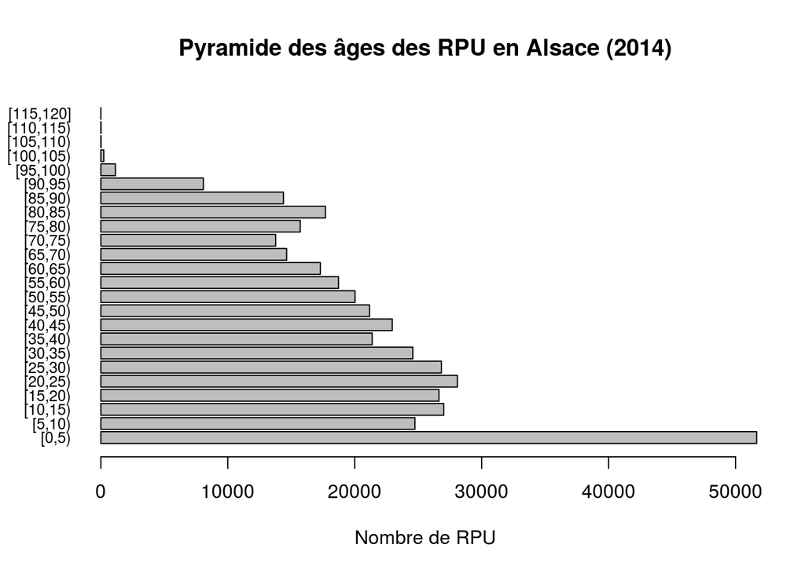

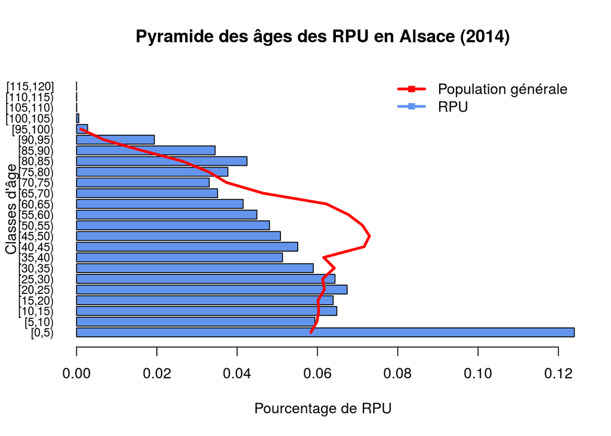

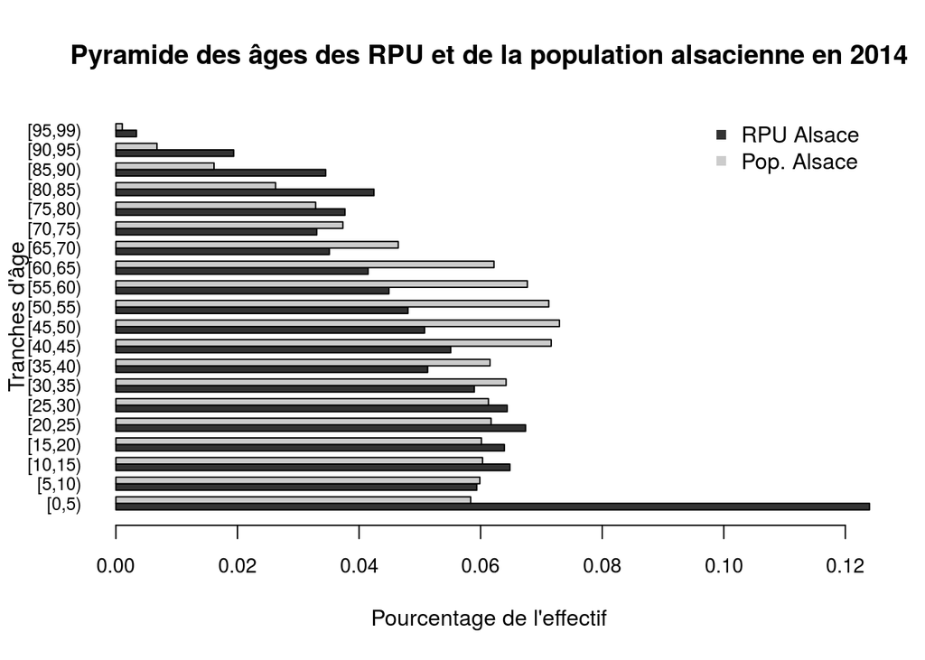

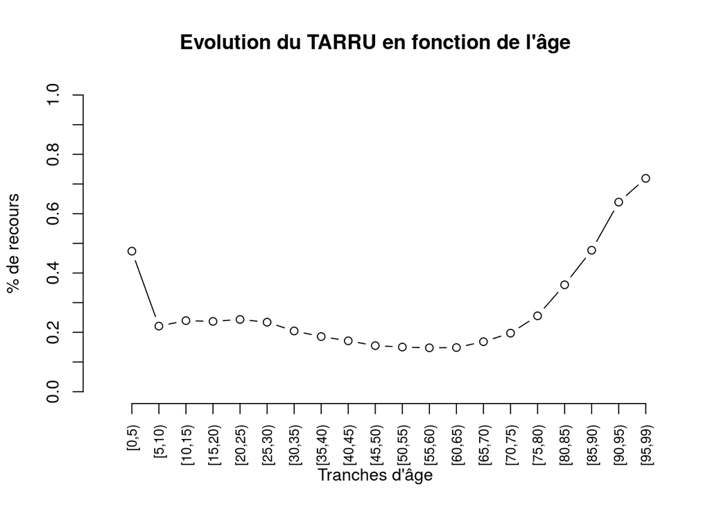

On obtient la même courbe enformant le rapport du % de RPU pour une classe d’age sur le % de cette classe d’âge dans la population:

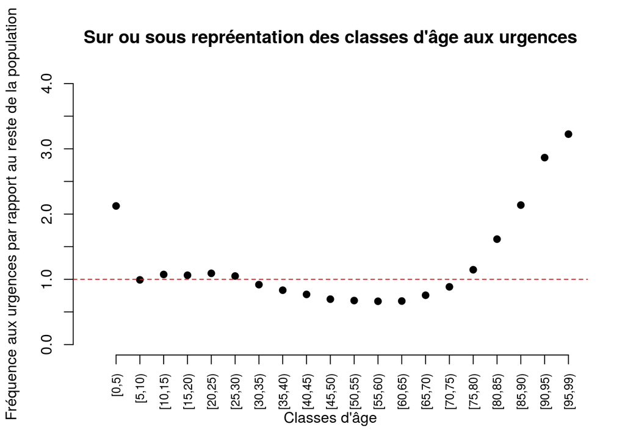

## Tableau des données

```
          RPU       p.rpu popAls    p.popAls      TARU
[0,5)   51663 0.123972654 109057 0.058357543 0.4737247
[5,10)  24738 0.059362319 111888 0.059872440 0.2210961
[10,15) 27012 0.064819103 112728 0.060321933 0.2396210
[15,20) 26631 0.063904840 112377 0.060134109 0.2369791
[20,25) 28086 0.067396318 115342 0.061720712 0.2435019
[25,30) 26827 0.064375169 114526 0.061284062 0.2342438
[30,35) 24574 0.058968778 119963 0.064193457 0.2048465
[35,40) 21374 0.051289927 115022 0.061549477 0.1858253
[40,45) 22952 0.055076561 133821 0.071609018 0.1715127
[45,50) 21162 0.050781203 136354 0.072964453 0.1551990
[50,55) 20022 0.048045612 133082 0.071213572 0.1504486
[55,60) 18720 0.044921280 126502 0.067692545 0.1479819
[60,65) 17290 0.041489793 116235 0.062198566 0.1487504
[65,70) 14635 0.035118746  86803 0.046449194 0.1686002
[70,75) 13772 0.033047856  69792 0.037346430 0.1973292
[75,80) 15707 0.037691161  61411 0.032861669 0.2557685
[80,85) 17692 0.042454449  49098 0.026272854 0.3603405
[85,90) 14385 0.034518836  30171 0.016144818 0.4767823
[90,95)  8076 0.019379501  12639 0.006763261 0.6389746
[95,99)  1411 0.003385893   1962 0.001049887 0.7191641
```